# PROJECT 3: DATA VISUALIZATION CASE STUDY

## Overview

We are to investigate and come with visuals on the chosen dataset i.e I chose the ford go bike data. This dataset includes information about individual rides made in a bike-sharing system covering the greater San Francisco Bay area.

Questions

When are most trips taken in terms of time of day, day of the week?

Which birth year with most riders?

Station with most and least rides?

Ford GoBike System Data: This data set includes information about individual rides made in a bike-sharing system covering the greater San Francisco Bay area.

**What time of the day are most trips made?**

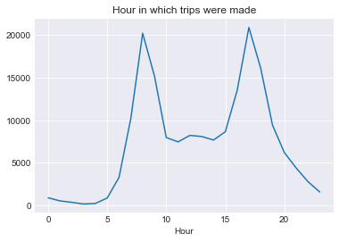

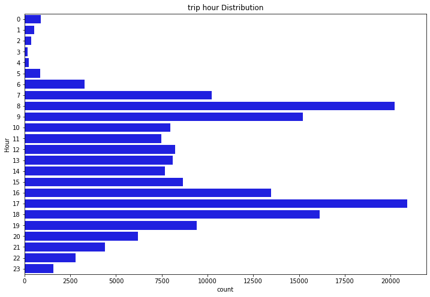

8 a.m and 5.00 pm is when most trips are made.

**which day of the week are most trips made?**

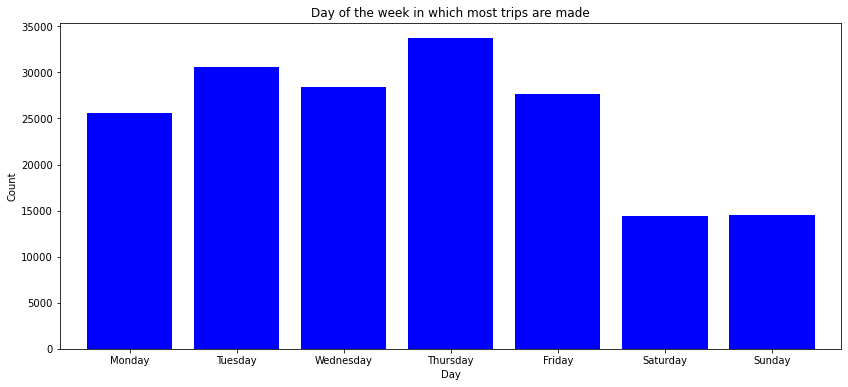

Most rides are made on Thursdays.

Generally most trips are made on weekdays and few on weekends.

**which day of the month were most trips made?**

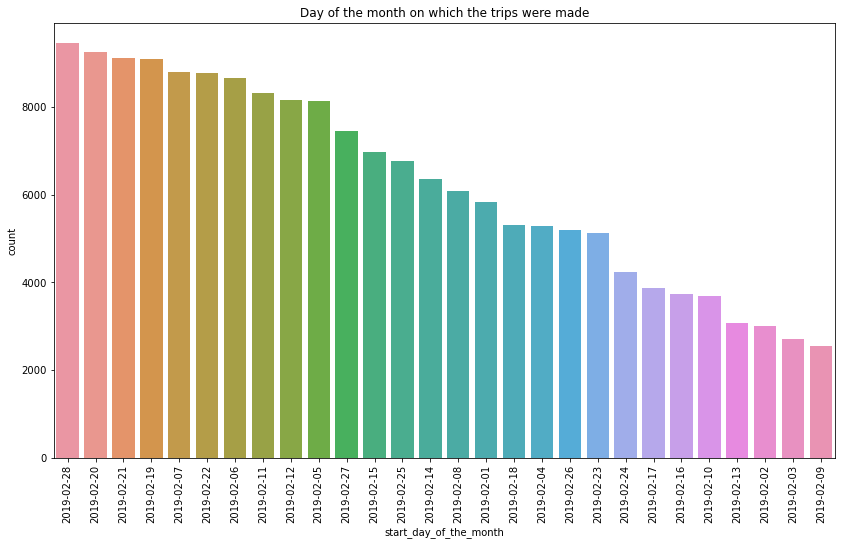

Most trips were made on 28th february and least on 9th february

**Birth year with most riders**

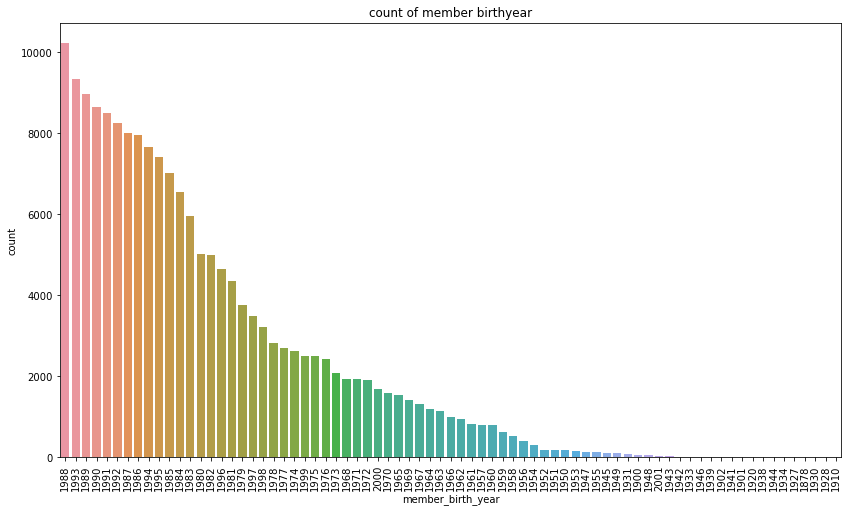

People born in 1988 were most

**Histogram for age**

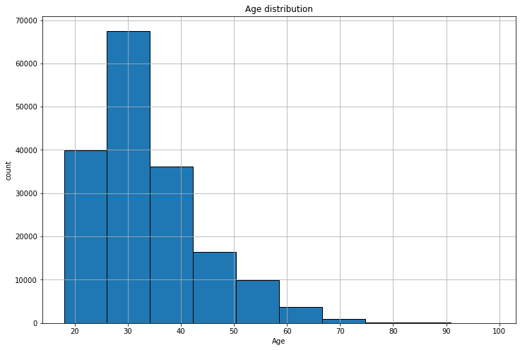

Most riders are between the age of 20 and 40

**Users with most bike riding**

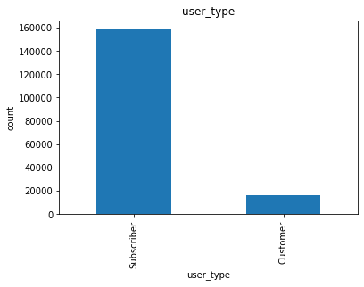

Most bike riding were made by subscribers

**Gender with most bike riding**

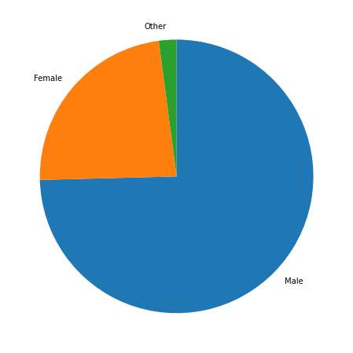

Males were also the most bike riders

**From the above:**

1) Most bike riding were made by subscribers

2) Males were also the most bike riders

**Stations with most and list riders**

[figure not shown]

Market st at 10th streets leads with most users.

16th st depot has the least bike riders

1) Distribution of Age against time spent in hours

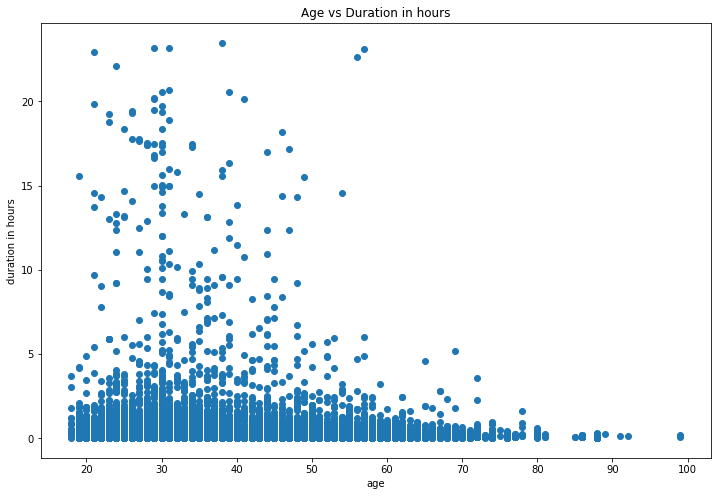

Most young people between 20 and 45 years cycle for more hours

2) user_type distribution with regards to age and duration in hours

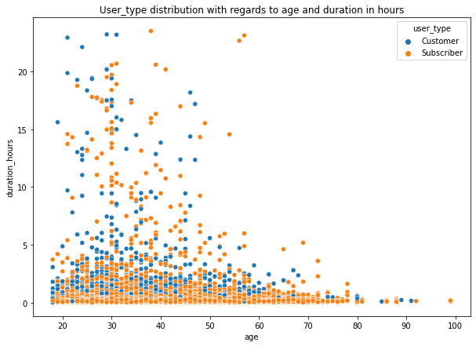

From the distribution most users spend less than 5 hours

**Age trend for the gender in terms of hour time**

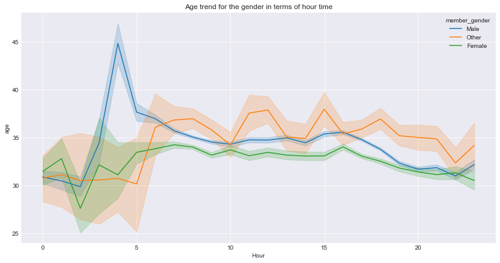

**visualizing distribution age of customers and subscribers**

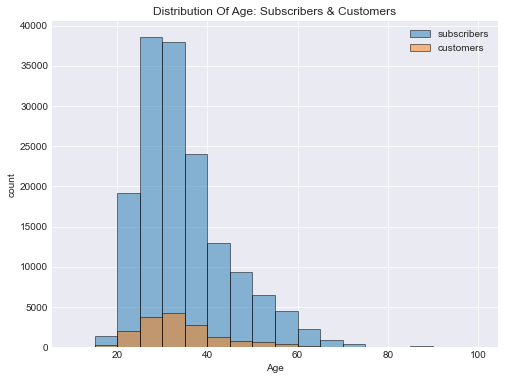

From the visual most of the subscribers and customers lie between 20 and 40 age bracket

**visualizing age count of male and females**

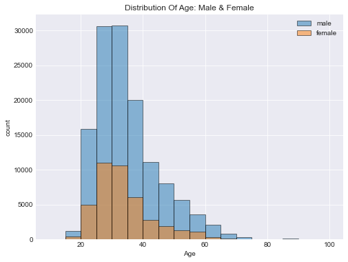

Also from the distribution generally most male and females lie between 20 and 40 years

**Heatmap for count of usertype and gender.**

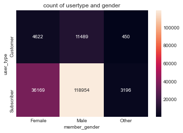

**Intepretation:**

From the above plot we have:

```
1) 36169 female subscribers
2) 118954 male subscribers
3) 3196 other gender subscribers

4) 4622 female customers
5) 11489 male customers
6) 450 other gender customers
```

**Distribution count of gender user type**

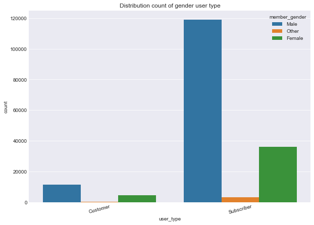

From the visual more males are enrolled to the bike sharing system.

**Trip duration for the users**

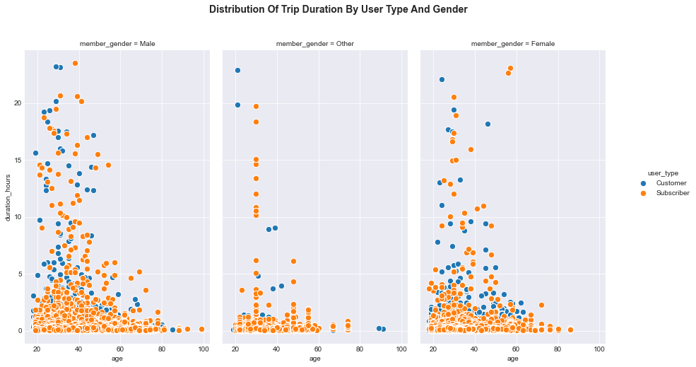

Again here more users take less than 5 hrs

# CONCLUSION

### Talk about some of the observations.

Most trips during the day were made at 8.00 am and 5.00pm this shows that most usere were workers and the bikes were used in rush hours

Most males used bikes as compared to other genders

Subscribers were more as compared to customers

### Were there any interesting or surprising interactions between features?

Not much, most observations were as expected:

> Most young people cycling for more hours with an exception of few aged individuals

> Subscribers were more as compared to customers